# Aprendizaje automático con criterio humano: restricciones monotónicas para decisiones consistentes

Gestión de datos en organizaciones - 4to encuentro interdisciplinar

Karina A. Bartolomé

Especialista en Métodos Cuantitativos para la Gestión y Análisis de Datos en Organizaciones (FCE, UBA). Lic. en Economía (FCE, UNLP). Líder técnica de Ciencia de Datos (Ualá).

2026-09-03

## 0.1 Consideraciones previas

- Se recomienda contar con conocimientos previos de modelos de aprendizaje automático y programación (python).
- Todo el código se encuentra disponible en [Repositorio](https://github.com/karbartolome/workshops)
- Durante el seminario se utilizarán los siguientes paquetes:

📦 `pandas` = 2.2.3  
📦 `numpy` = 1.26.4  
📦 `scikit-learn` = 1.5.2  
📦 `matplotlib` = 3.9.2  
📦 `seaborn` = 0.13.2

**Environment**: `ds_model/1.0/.venv/bin/python`  
**Python version**: `3.12.13 (main, Aug 7 2026, 02:15:23) [Clang 22.1.3 ]`

# 1 Introducción a modelos de Machine Learning

## 1.1 Modelos

El desarrollo de modelos predictivos implica encontrar una relación entre N variables explicativas (X) y una variable objetivo (y).

$$y = f(X)$$

Esta relación es una función en modelos simples pero en modelos más complejos (ensambles, redes neuronales, etc.) no es tan claro el efecto de cada variable sobre la variable objetivo.

## 1.2 Actores involucrados

**Datos → Modelo → Predicción → Decisión → Impacto**

En el ciclo de vida de los modelos predictivos intervienen diversos actores (Molnar 2025):

- **Creadores**: desarrollan y entrenan el modelo.
- **Operadores**: interactúan directamente con el sistema.
- **Ejecutores**: toman decisiones a partir de sus predicciones.
- **Afectados** (decision subjects): reciben las consecuencias de esas decisiones.
- **Data subjects**: aportan los datos utilizados para entrenar el modelo.
- **Auditores**: evalúan, investigan y controlan el funcionamiento del sistema.

→ Cada actor puede necesitar una explicación diferente

# 2 Interpretabilidad de modelos

## 2.1 XAI: Explainable AI

La **Inteligencia Artificial Explicable (XAI)** reúne métodos y técnicas que permiten describir el comportamiento de un modelo y comunicar por qué produce una predicción determinada (Molnar 2025).

Una explicación debería ayudar a una persona a:

- **Entender** qué variables influyen en el modelo y en qué dirección.
- **Evaluar** si la predicción es razonable y consistente con el conocimiento de dominio.
- **Detectar** errores, sesgos o comportamientos inesperados.
- **Auditar** el sistema y justificar una decisión ante otras personas.

## 2.2 XAI: Explainable AI (Cont.)

**Dos niveles de explicación**

- **Global**: describe el comportamiento general del modelo, por ejemplo, qué variables son importantes o cómo cambia la predicción en promedio.
- **Local**: explica una predicción particular, por ejemplo, por qué una persona recibió una determinada estimación de riesgo.

> Una explicación describe el comportamiento del modelo; no necesariamente representa una relación causal del mundo real.

## 2.3 Interpretación de modelos de Machine Learning

Existe un *trade off* entre la interpretabilidad y poder predictivo (*performance*) de los modelos (Figura 1).

Quienes toman decisiones necesitan entender cómo funciona el modelo para poder confiar en él y tomar decisiones consistentes con su conocimiento de dominio.

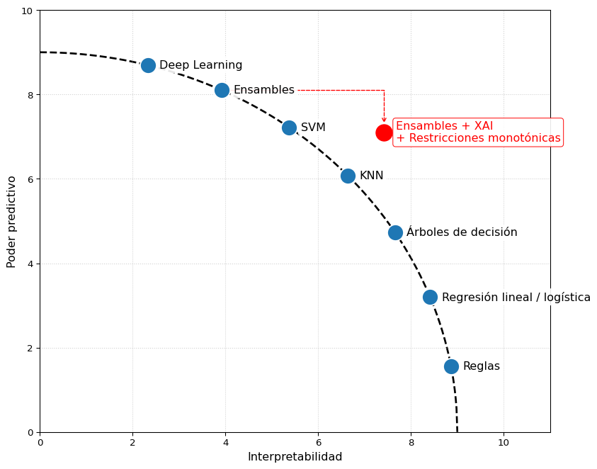

Figura 1: Trade-off interpretabilidad vs. poder predictivo (Gunning y Aha 2019).

## 2.4 Explicabilidad de modelos

Al desarrollar modelos supervisados de Machine Learning, se suele contar con conocimiento de dominio. Las **buenas explicaciones de modelos deben ser consistentes con las creencias previas** del usuario del modelo (Molnar 2025). Una forma de incorporar esto en los modelos es mediante el uso de **restricciones monotónicas**.

> Ejemplos de conocimiento de dominio: - **Predicción de precios de propiedades**: se espera que a mayor cantidad de $m^2$, mayor precio. - **Predicción de riesgo de crédito**: se espera que a mayor edad, menor probabilidad de default.

# 3 Restricciones monotónicas

## 3.1 Monotonicidad

- Una función es **monotónica creciente** si, cuando aumenta el valor de entrada, su salida no disminuye:
  - `Si x1 <= x2: f(x1) <= f(x2)`
- Una función es **monotónica decreciente** si, cuando aumenta el valor de entrada, su salida no aumenta:
  - `Si x1 <= x2: f(x1) >= f(x2)`

En machine learning, una **restricción monotónica** fuerza al modelo a respetar una dirección esperada entre una variable y la predicción. Esto puede ser útil para incorporar conocimiento de dominio, reducir comportamientos contraintuitivos y mejorar la interpretabilidad y auditoría de los modelos.

Ejemplo: si se espera que al aumentar la edad caiga la probabilidad de cierto evento, se puede imponer una restricción monotónica decreciente sobre `edad`.

## 3.2 Monotonicidad creciente

La función `f(x) = x ** 2` es monotónica creciente para valores de `x >= 0`: si `x` aumenta, `f(x)` también aumenta o se mantiene igual.

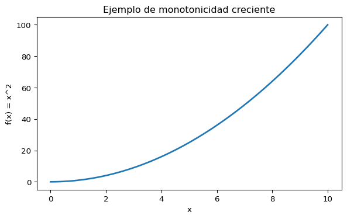

## 3.3 Monotonicidad decreciente

La función `f(x) = exp(-x)` es monotónica decreciente: si `x` aumenta, `f(x)` disminuye.

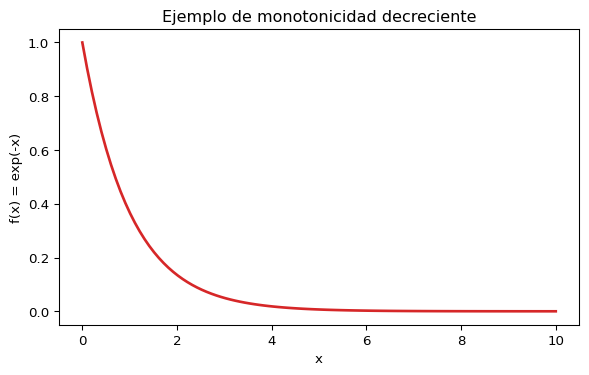

## 3.4 Modelo con restricciones monotónicas

**Datos simulados**

```python
rng = np.random.default_rng(42)
n_total = 1000
monto = rng.integers(1000, 30001, size=n_total)

base_prob = 1 / (1 + np.exp(-(monto - 12000) / 3500))
ondulacion = 0.05 * np.sin(monto / 1800)
ruido = rng.normal(0, 0.1, size=n_total)

prob_default = np.clip(base_prob + ondulacion + ruido, 0.01, 0.99)
target = rng.binomial(1, prob_default, size=n_total)

df_full = pd.DataFrame({"monto": monto, "target": target})
df = df_full.sample(n=100, random_state=42).sort_values("monto").reset_index(drop=True)

X = df[["monto"]]
y = df["target"]
```

Tabla 1: Datos simulados (muestra de 4 observaciones)

| target | monto |
| --- | --- |
| 1 | $25,644.00 |
| 1 | $17,451.00 |
| 1 | $23,268.00 |
| 1 | $14,858.00 |

Se espera que la probabilidad de *default* aumente ante un mayor monto del crédito otorgado. Se ajusta un modelo de clasificación binaria con y sin restricción sobre la variable `monto`.

**Modelos con y sin restricción monotónica**

```python
# Modelo sin represtricción monotónica
modelo_sin_restriccion = HistGradientBoostingClassifier(
    max_depth=4, max_iter=100, learning_rate=0.1, random_state=42
)
modelo_sin_restriccion.fit(X, y)

# Con restricción monotónica creciente sobre la variable `monto` (índice 0)
modelo_con_restriccion = HistGradientBoostingClassifier(
    max_depth=4,
    max_iter=100,
    learning_rate=0.1,
    monotonic_cst={"monto": 1},
    random_state=42,
)
modelo_con_restriccion.fit(X, y)
```

```
HistGradientBoostingClassifier(max_depth=4, monotonic_cst={'monto': 1},
                               random_state=42)
```

## 3.5 Modelo con restricciones monotónicas (Cont.)

En la Figura 2 (a) se observan los datos simulados. En la Figura 2 (b) se comparan las predicciones de los modelos con y sin restricción monotónica creciente sobre la variable `monto`.

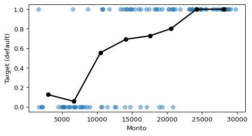

(a) Datos simulados

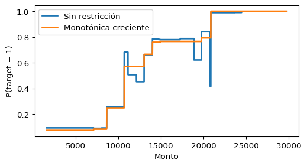

(b) Probabilidad estimada de default

Figura 2: Comparación de modelos con y sin restricción monotónica

- Modelo sin restricción: la probabilidad de *default* disminuye para ciertos rangos de `monto` (contraintuitivo).
- Modelo con restricción: respeta la relación esperada entre `monto` y la probabilidad de *default*.

# 4 Caso: scoring crediticio

## 4.1 Datos

*GiveMeSomeCredit* es un dataset de scoring crediticio con información financiera y demográfica de individuos. El objetivo es modelar el riesgo de incumplimiento (*default*) a partir de esas características.

**Lectura de datos**

```python
df = pd.read_csv(f"{PATH_DATA}/cs-training.csv").drop("Unnamed: 0", axis=1)


FEATURES = ["age", "DebtRatio"]

X = df[FEATURES]
y = df[TARGET]

X_train, X_test, y_train, y_test = train_test_split(
    X, y, test_size=0.3, random_state=42, stratify=y
)

N_OBSERVACIONES = df.shape[0]
N_VARIABLES = df.shape[1]
PERC_DEFAULT = y.mean()

N_TRAIN = X_train.shape[0]
N_TEST = X_test.shape[0]
```

Se cuenta con un dataset de 150000 observaciones y 11 variables, con 105000 observaciones en el dataset de entrenamiento y 45000 en el dataset de evaluación.

- ¿Cuál es la probabilidad de *default* de un individuo dadas ciertas características?
- ¿Cómo cambia esa probabilidad para un individuo si aumenta una variable, manteniendo el resto de las variables constantes?

## 4.2 Análisis exploratorio de datos

[figure not shown]

Figura 3: Distribución del riesgo de incumplimiento y de DebtRatio

La variable `DebtRatio` mide la relación entre deuda e ingreso mensual. Para el modelo se acota al intervalo $[0, 1]$, evitando que valores extremos dominen la visualización.

## 4.3 Modelo

Se seleccionan `Age` y `DebtRatio` para enfocar el análisis en relaciones que puedan expresarse como conocimiento de dominio.

**Preprocesamiento y ajuste**

```python
def clip_debt_ratio(data):
    data = data.copy()
    data["DebtRatio"] = data["DebtRatio"].clip(0, 1)
    return data

debt_ratio_preprocessor = FunctionTransformer(
    clip_debt_ratio,
    feature_names_out="one-to-one",
)

X_train = debt_ratio_preprocessor.fit_transform(X_train)
X_test = debt_ratio_preprocessor.transform(X_test)

modelo_sin_restriccion_credito = CatBoostClassifier(
    iterations=100,
    depth=8,
    verbose=0,
    random_seed=42,
)
modelo_sin_restriccion_credito.fit(X_train, y_train)
```

```
<catboost.core.CatBoostClassifier at 0x13ec1adb0>
```

El primer modelo no incorpora restricciones. Su flexibilidad permite capturar relaciones complejas, pero también puede producir cambios contraintuitivos en regiones con pocos datos.

## 4.4 Modelo (Cont.)

### Dependencia parcial

La dependencia parcial muestra cómo cambia, en promedio, la predicción cuando se modifica una variable y se mantienen las demás distribuciones observadas.

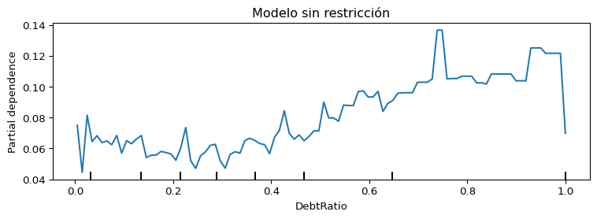

Figura 4: Dependencia parcial de DebtRatio para el modelo sin restricción

## 4.5 Modelo con restricciones monotónicas

Se espera que un mayor endeudamiento no reduzca el riesgo de incumplimiento. Por eso se impone una restricción monotónica creciente sobre `DebtRatio`.

**Ajuste con restricción monotónica**

```python
restricciones = {"DebtRatio": 1}

modelo_con_restriccion_credito = CatBoostClassifier(
    iterations=100,
    depth=8,
    monotone_constraints=restricciones,
    verbose=0,
    random_seed=42,
)
modelo_con_restriccion_credito.fit(X_train, y_train)
```

```
<catboost.core.CatBoostClassifier at 0x13fcb9520>
```

La restricción no obliga a que todos los individuos tengan el mismo riesgo. Obliga a que, manteniendo las demás variables constantes, el riesgo estimado no disminuya cuando aumenta `DebtRatio`.

## 4.6 Comparación de modelos

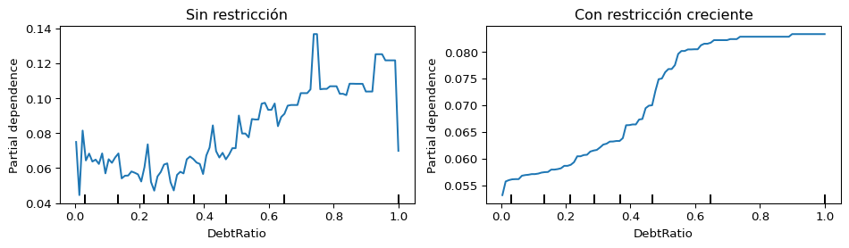

Figura 5: Dependencia parcial de DebtRatio con y sin restricción monotónica

Para observar el efecto en una decisión concreta, se simula una persona de 30 años y se aumenta su `DebtRatio` de 0.75 a 0.85.

|  | Modelo | P(default), DebtRatio = 0.75 | P(default), DebtRatio = 0.85 | Cambio |
| --- | --- | --- | --- | --- |
| 0 | Sin restricción | 11.0% | 10.4% | -0.7% |
| 1 | Con restricción | 11.9% | 11.9% | +0.0% |

El modelo restringido mantiene el sentido esperado del cambio: un aumento en `DebtRatio` no puede producir una reducción de la probabilidad estimada de incumplimiento.

## 4.7 Referencias / Recursos

Gunning, David, y David Aha. 2019. «DARPA’s Explainable Artificial Intelligence (XAI) Program». *AI Magazine* 40 (2): 44-58. https://doi.org/10.1609/aimag.v40i2.2850.

Molnar, Christoph. 2025. *Interpretable Machine Learning: A Guide for Making Black Box Models Explainable*. 3.ª ed. https://christophm.github.io/interpretable-ml-book.

## 4.8 Contacto

[karinabartolome](https://www.linkedin.com/in/karinabartolome/)

karbartolome

karbartolome

[Blog](https://karbartolome-blog.netlify.app/)

[figure not shown]

Cimbage - IADCOM | Facultad de Ciencias Económicas - UBA